# R Notebook

** Peak of seat offering in 2022 with sharp decline in 2023. Journalism can be STEM oriented but mostly leans towards the humanities and is generally treated as such. The department offered its least amount of seats in 2023, with the same drastic drop as the English department. This leads us to ask what third independent variable was affecting humanities departments? It could be university policies, enrollment trends, economic pressures (job market) or instructor availability.

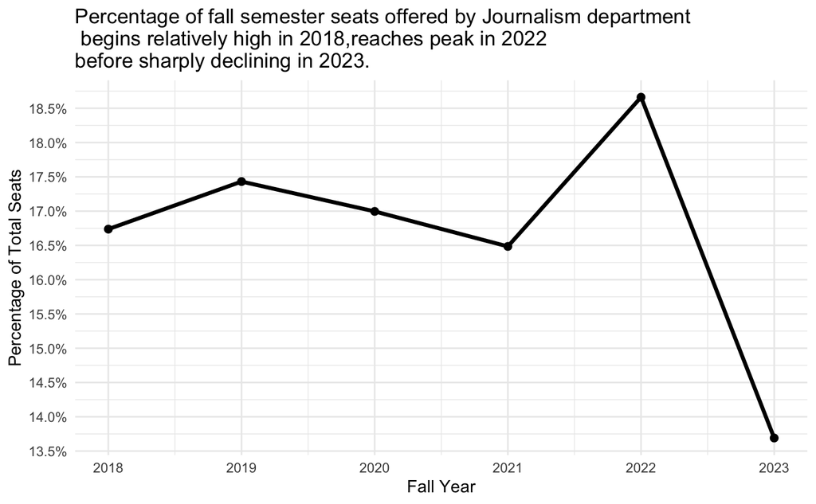

```r
ggplot(seats_by_year_journalism, aes(x = year, y = percent_of_total, group = 1)) +
  geom_line(size = 1.2) +
  geom_point(size = 2) +
  scale_y_continuous(
    n.breaks = 10,
    labels = scales::percent_format(scale = 1)
  ) +
  labs(
    title = "Percentage of fall semester seats offered by Journalism department\n begins relatively high in 2018,reaches peak in 2022\nbefore sharply declining in 2023.",
    x = "Fall Year",
    y = "Percentage of Total Seats"
  ) +
  theme_minimal()
```

Q2: Which departments had the least amount of professors across the years? which ones had the most? Are there any patterns in the results?

```r
prof_to_depart <- courses_fall_spring |>
   group_by(department, term) |>
  summarise(
    total_prof_depart = n_distinct(instructors)
  ) |>
  arrange(desc(total_prof_depart))

seats_to_depart <- courses_fall_spring |>
group_by(department, term) |>
summarise(
  total_seats_depart = sum(seats)
) |>
  arrange(desc(total_seats_depart))
```

Q3: [wildcard] Search the description column for keywords of interest and discuss findings (if a pattern is found, if not keep searching relevant words)

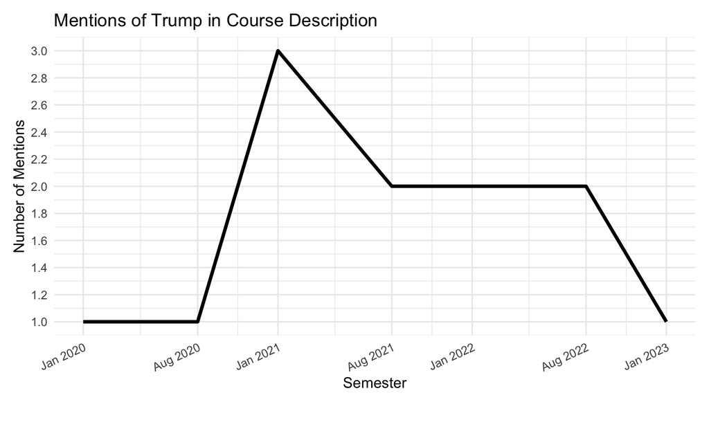

```r
trump_courses <- courses_fall_spring |>
  mutate( title = str_to_upper(title), description = str_to_upper(description)) |>
  filter(str_detect(description, "TRUMP"))|>
  group_by(start_date) |>
summarise(
  semester_total = n(),
  .groups = "drop"
) |>
arrange(desc(start_date))


trump_courses |>
  ggplot() +
  geom_line(aes(x=start_date, y=semester_total), size=1.2)+

labs(title = "Mentions of Trump in Course Description", x= "Semester", y = "Number of Mentions")+
  scale_y_continuous(n.breaks = 15) +
    scale_x_date(
    breaks = artificial_intelligence$start_date,
    date_labels = "%b %Y"
  ) +
  theme_minimal()+
   theme(
    axis.text.x = element_text(angle = 25,  hjust=1),
     plot.margin = margin(10, 10, 35, 10)
  )
```

Q4: Is there a change in the mentions of Artificial intelligence in courses?

A4: Through this question we hoped to find out whether the recent uptick in AI usage throughout the world is reflected in the course offerings at UMD. While this data set is two years old there is still a significant increase in the number of courses with a focus on AI. The biggest increase was from the Fall 2022 semester to the Spring 2023 semester where the number of courses more than doubled. This is likely due to the release of ChatGPT in November of 2022. Even though the number of courses dropped again in Fall 2023, it shows how there was a continued interest in AI throughout UMD.

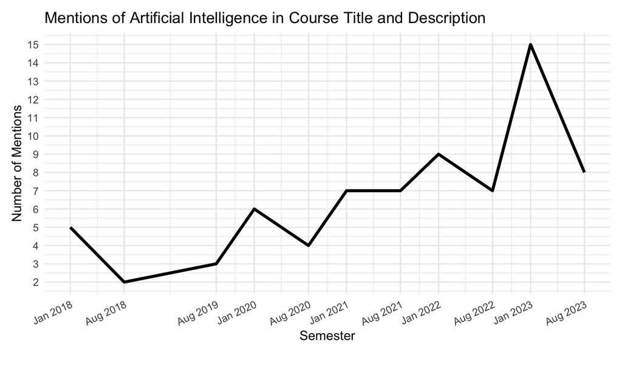

```r
artificial_intelligence <- courses_fall_spring |>
  mutate( title = str_to_upper(title), description = str_to_upper(description)) |>

  filter(
    str_detect(title,"ARTIFICIAL INTELLIGENCE") | str_detect(description, "ARTIFICIAL INTELLIGENCE") | str_detect(title, " AI ") | str_detect(description, " AI ")) |>
  group_by(start_date) |>
summarise(
  semester_total = n(),
  .groups = "drop"
) |>
arrange(desc(start_date))

artificial_intelligence |>
  ggplot() +
  geom_line(aes(x=start_date, y=semester_total), size=1.2)+

labs(title = "Mentions of Artificial Intelligence in Course Title and Description", x= "Semester", y = "Number of Mentions")+
  scale_y_continuous(n.breaks = 15) +
    scale_x_date(
    breaks = artificial_intelligence$start_date,
    date_labels = "%b %Y"
  ) +
  theme_minimal()+
   theme(
    axis.text.x = element_text(angle = 25,  hjust=1),
     plot.margin = margin(10, 10, 35, 10)
  )
```

```r
NA
```

**Q5** What school has had the most classes removed as the semesters go by? (Or calculate the percent change from the department

```r
department_ref <- umd_courses |>
  separate_rows(department, sep = ";") |>
  mutate(department = trimws(department)) |>
  select(department) |>
  distinct()

department_ref
```

| department |
| --- |
| Linguistics |
| American Studies |
| Engineering, Civil |
| Education Counseling and Personnel Services |
| Criminology and Criminal Justice |
| Health |
| Geographical Sciences |
| Hebrew |
| Art History & Archaeology |
| Engineering Science |

[output cut: 200 more lines]

```r
#classes per semester

classes_per_department <- umd_courses |>
  separate_rows(department, sep = ";") |>
  mutate(department = trimws(department)) |>
  group_by(department)|>
  summarize(class_count = n())

classes_per_department
```

| department | class_count |
| --- | --- |
| ACES-Cybersecurity | 178 |
| Academy for Innovation & Entrepreneurship | 70 |
| Accounting and Information Assurance | 171 |
| African American Studies | 420 |
| Agricultural Science and Technology | 24 |
| Agricultural and Resource Economics | 320 |
| Agriculture and Natural Resources | 52 |
| Air Science | 56 |
| American Studies | 493 |
| Animal Science | 478 |

[output cut: 200 more lines]

```r
#-- SEMESTERS--#

#terms ref
termsem <- umd_courses |>
  select(term) |>
  distinct()|>
  arrange(desc(term))

termsem
```

| term |
| --- |
| 202308 |
| 202305 |
| 202301 |
| 202212 |
| 202208 |
| 202205 |
| 202201 |
| 202112 |
| 202108 |
| 202105 |

[output cut: 12 more lines]

```r
#There's 22 terms in this dataset. Should i create a  dataframe that filter each term and group by department to summarize the class count... 22 times OR find a loop code -->  I'll try to create a loop

#trying out loops, trying to remember if the python rules apply

#Making a vector with the list of terms I had outputted in previous data set
terms_vector <- unique(termsem$term)

#Make an empty list
results_list_terms <- list()

#Creating loop using the for every term in the term list vector, they will output results...

for (term in terms_vector) {
  results <- umd_courses |>
    separate_rows(department, sep = ";") |>
  mutate(department = trimws(department))|>
  filter(term == !!term) |> # the !! forces the code to look at the values under term column as its own dataframe so that the filter can work -- only a tidyverse thing
  group_by(department)|>
  summarize(class_count = n())

  results <- results |> mutate(term = term)
results_list_terms[[as.character(term)]] <-results
}

final_term_list <- bind_rows(results_list_terms,.id = "term")


#Widening the data set so it's easier to read. So that each term is in its own column instead of a part of a terms row. Essentially flipping the data frame  axis
depart_class_termlist  <- final_term_list|>
  pivot_wider(names_from = term, #specifying the unique term semesters are their own column name
              values_from = class_count, #class_count values will transfer to new columns; under each term
              names_prefix = "term_")

#Joining the total classes dataframe into the previous one
depart_class_termlist_2 <- depart_class_termlist |>
  left_join(classes_per_department, by = "department") |>
    rename(
      total_count = class_count
      #should i rename the term columns? lazy rn no shade.
    )


#print tibble
depart_class_termlist
```

| department | term_202308 | term_202305 | term_202301 | term_202212 | term_202208 | term_202205 | term_202201 | term_202112 | term_202108 | term_202105 | term_202101 | term_202012 | term_202008 | term_202005 | term_202001 | term_201912 | term_201908 | term_201905 | term_201808 | term_201805 | term_201801 | term_201712 |
| --- | --- | --- | --- | --- | --- | --- | --- | --- | --- | --- | --- | --- | --- | --- | --- | --- | --- | --- | --- | --- | --- | --- |
| ACES-Cybersecurity | 14 | NA | 17 | NA | 16 | NA | 15 | NA | 14 | 4 | 16 | NA | 14 | 4 | 15 | NA | 13 | 4 | 15 | 4 | 13 | NA |
| Academy for Innovation & Entrepreneurship | 6 | NA | 8 | NA | 9 | NA | 9 | NA | 7 | NA | 10 | NA | 9 | NA | 5 | NA | 4 | 1 | NA | 1 | 1 | NA |
| Accounting and Information Assurance | 16 | NA | 12 | NA | 17 | NA | 12 | NA | 16 | NA | 12 | NA | 19 | 2 | 11 | NA | 19 | 2 | 18 | NA | 15 | NA |
| African American Studies | 26 | 8 | 35 | 4 | 34 | 13 | 23 | 3 | 27 | 9 | 28 | 4 | 26 | 11 | 32 | 5 | 34 | 10 | 35 | 13 | 34 | 6 |
| Agricultural Science and Technology | 6 | NA | 4 | NA | 5 | 1 | 1 | NA | 5 | NA | NA | NA | 2 | NA | NA | NA | NA | NA | NA | NA | NA | NA |
| Agricultural and Resource Economics | 27 | 7 | 27 | 2 | 24 | 6 | 29 | 2 | 25 | 6 | 25 | 2 | 27 | 6 | 24 | 2 | 22 | 6 | 26 | 6 | 18 | 1 |
| Agriculture and Natural Resources | 5 | 3 | 4 | NA | 5 | 3 | 3 | NA | 4 | 3 | 3 | NA | 4 | NA | 2 | NA | 4 | NA | 5 | NA | 4 | NA |
| Air Science | 5 | NA | 5 | NA | 5 | NA | 5 | NA | 5 | NA | 5 | NA | 5 | NA | 5 | NA | 5 | NA | 5 | NA | 6 | NA |
| American Studies | 35 | 10 | 41 | 4 | 42 | 11 | 33 | 4 | 34 | 10 | 36 | 5 | 36 | 10 | 40 | 6 | 40 | 11 | 33 | 9 | 39 | 4 |
| Animal Science | 38 | 8 | 41 | 7 | 40 | 8 | 42 | 7 | 33 | 6 | 39 | 5 | 33 | 6 | 41 | 5 | 33 | 6 | 29 | 7 | 39 | 5 |

[output cut: 200 more lines]

```r
avg_percent_change <- depart_class_termlist |>
  select(department, starts_with("term_")) |>
  pivot_longer(cols = starts_with("term_"),  #long format
               names_to = "term",
               values_to = "class_count") |>
  group_by(department) |>
  arrange(term) |>  #  the terms are in order i guess
  mutate(percent_change = (class_count - lag(class_count)) / lag(class_count) * 100) |>  # percent change
  summarise(average_percent_change = mean(percent_change, na.rm = TRUE)) |>
  ungroup()


#arrange from high percent change to low
avg_percent_change |>
  arrange(desc(average_percent_change))
```

| department | average_percent_change |
| --- | --- |
| Physics | 1434.995601 |
| School of Music | 1111.850227 |
| University Honors | 944.928549 |
| Jewish Studies | 899.970254 |
| Engineering, Professional Masters | 855.172967 |
| Dance | 772.851851 |
| Journalism | 646.137115 |
| Institute of Applied Agriculture | 629.093102 |
| Engineering, Aerospace | 617.052883 |
| Italian | 605.000000 |

[output cut: 200 more lines]

```r
NA
NA
NA
```

** Final Story Memo